# Workshop1

2023-07-27

# Workshop 1️⃣ Exploratory Data Analysis & Study Design

**🎯 Goals of this Workshop**

1. Explore the Dataset
2. Define Inclusion and Exclusion Criteria to build a working cohort
3. Create visualizations and explore the variables’ distributions
4. Define the target and objective of the model to build with the data set

**✏️ Expected Deliverables**

1. Flow diagram with inclusion and exclusion criteria, reporting who’s being left out, by demographics
2. Define the Machine Learning Task to be addressed

**❗ Highlighted Pitfall(s)**

1. Sampling and Representation Bias

## 0. Understand the Problem and Dataset

Please go through [Workshop 0](https://github.com/MIT-LCP/bst209/blob/main/datathon/introduction/introduction.html) for an Introduction on the Problem, Dataset and Objective of the Datathon.

## 1. Inclusion/Exclusion Criteria Definition

In discussion between Data Scientists and Clinicians, try to answer these questions:

- What is a reasonable $SaO_2$ and $SpO_2$ cut-off value to avoid aberrant values and venous blood gas value?
- What is a reasonable time offset between $SaO_2$ and $SpO_2$ to create a pair?
- Are there patients from any demographics or with certain comorbidities that should not be included?
- Is there any specific treatment information that may influence?
- How to deal with multiple pairs per patient?

When taking these decisions, keep these into consideration:

- Are we keeping a reasonable amount of patients?
- What are the consequences of these decisions if we were to implement the result of this project in a real setting?
- Are we seggregating any group of patients?
- Are there groups that are more likely to be dropped in any approach and could introduce sampling selection bias?

## 2. Study Cohort Creation

**What is a Flowchart in this context?**

A Flowchart reflects the study cohort creation, by selecting the patients that best suit our study design.

It is a helpful tool to visualize the numbers after applying our inclusion and exclusion criteria.

**Example (part of one):**

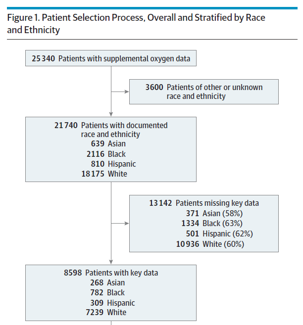

### ✏️ Initial Exploratory Data Analysis (EDA)

```r
library(dplyr)
data <- read.csv("../mimic_pulseOx_data.csv")
# print(head(data,1))
```

`Create code below to answer the following questions`

How many patients do we have per racial-ethnic group, sex, and other demographics?

```r
# Calculate the proportions
sex_female_counts <- table(data$sex_female)
sex_female_proportions <- prop.table(sex_female_counts)

# Print the proportions
print(sex_female_proportions)
```

```
##
##         0         1
## 0.6466496 0.3533504
```

```r
print(prop.table(table(data$race_group)))
```

```
##
##      Asian      Black   Hispanic      Other      White
## 0.02731152 0.06900009 0.03448782 0.19428585 0.67491473
```

```r
print(prop.table(table(data$language)))
```

```
##
##         ?   ENGLISH
## 0.1136105 0.8863895
```

What is the $SaO_2$ / $SpO_2$ measurement values range?

```r
summary(data$SaO2)
```

```
##     Min.  1st Qu.   Median     Mean  3rd Qu.     Max.
##      0.0     95.0     97.0    254.7     98.0 999999.0
```

```r
summary(data$SpO2)
```

```
##    Min. 1st Qu.  Median    Mean 3rd Qu.    Max.
##    0.00   95.00   98.00   96.79  100.00  147.00
```

What is the typical $SaO_2$ - $SpO_2$ time offset?

```r
summary(data$delta_SpO2)
```

```
##    Min. 1st Qu.  Median    Mean 3rd Qu.    Max.
##  -90.00  -40.00  -24.00  -26.01  -11.00    0.00
```

```r
median(data$delta_SpO2, na.rm = TRUE)
```

```
## [1] -24
```

Does that offset significantly vary for certain groups?

```r
white_median <- median(data[data$race_group == "White",]$delta_SpO2, na.rm = TRUE)
cat("We're only looking at White patients. Their median delta_SpO2 is:", white_median, "minutes.")
```

```
## We're only looking at White patients. Their median delta_SpO2 is: -23 minutes.
```

```r
black_median <- median(data[data$race_group == "Black",]$delta_SpO2, na.rm = TRUE)
cat("We're only looking at Black patients. Their median delta_SpO2 is:", black_median, "minutes.")
```

```
## We're only looking at Black patients. Their median delta_SpO2 is: -24 minutes.
```

How many pairs do we have per patient?

```r
data %>%
  group_by(hadm_id) %>%
  summarise(count = n()) %>%
  .$count %>%
  summary()
```

```
##    Min. 1st Qu.  Median    Mean 3rd Qu.    Max.
##   1.000   1.000   2.000   5.308   5.000 273.000
```

Are there groups with different no. pairs?

```r
data_white <- data[data$race_group == "White",]

data_white %>%
  group_by(hadm_id) %>%
  summarise(count = n()) %>%
  .$count %>%
  summary()
```

```
##    Min. 1st Qu.  Median    Mean 3rd Qu.    Max.
##    1.00    1.00    2.00    5.17    5.00  273.00
```

```r
data_black <- data[data$race_group == "Black",]

data_black %>%
  group_by(hadm_id) %>%
  summarise(count = n()) %>%
  .$count %>%
  summary()
```

```
##    Min. 1st Qu.  Median    Mean 3rd Qu.    Max.
##   1.000   1.000   2.000   4.775   4.000 212.000
```

These questions are mere examples. Which other questions are relevant?

```r
# Code here!
```

```r
# Code here!
```